# My Study Time Patterns: A Visual Exploration

## What’s going on with this data?

This visual story explores my study habits over several weeks, tracking time spent on different courses and comparing weekday vs weekend patterns. The data was collected daily using a simple tracking system.

## Plot1: Study Hours: Weekdays vs Weekends

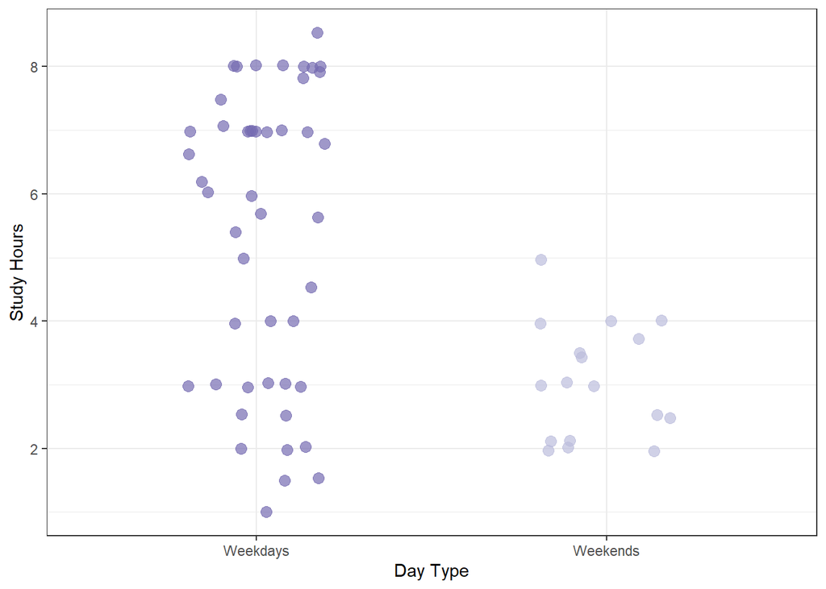

This scatter plot visualizes the distribution of study hours between weekdays and weekends. The chart shows that study hours are generally higher and more frequent on weekdays, with several sessions reaching around 8 hours. In contrast, weekends exhibit fewer study sessions with generally lower study hours. This suggests that study habits are more intensive on weekdays compared to weekends.

## Plot2: Course-Specific Study Patterns

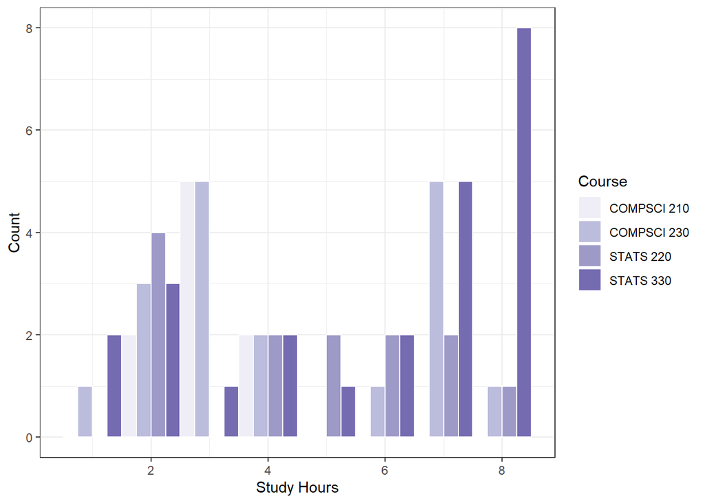

This histogram displays the distribution of study hours for four courses: COMPSCI 210, COMPSCI 230, STATS 220, and STATS 330. Study hours vary across courses, with STATS 330 showing the highest concentration of study sessions at around 8 hours. In contrast, COMPSCI 210 and COMPSCI 230 have more frequent study sessions around 2-4 hours. STATS 220 shows a balanced distribution across different study durations, indicating varied study habits. The chart suggests that students in STATS 330 tend to engage in longer study sessions compared to other courses.

## Plot3: Course Allocation by Day Type

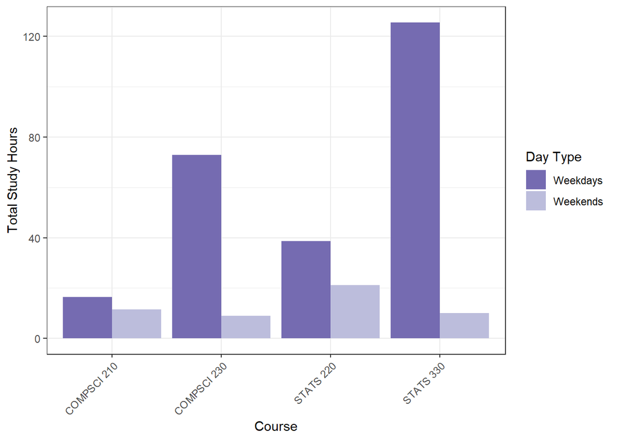

## Key Insights and Reflections

Peak Study Times: My longest study sessions consistently occur on weekdays

Course Focus: STATS 330 requires the most study time overall

```
## [1] 305.4
```

```
## [1] Wed
## Levels: Sun < Mon < Tue < Wed < Thu < Fri < Sat
```

## Summary

This analysis explores the study habits of myself across four courses (COMPSCI 210, COMPSCI 230, STATS 220, and STATS 330), focusing on the distribution of study hours between weekdays and weekends.

Study Hours Distribution (Weekdays vs. Weekends):

Weekdays show a significantly higher number of study sessions, with many reaching up to 8 hours.

In contrast, weekends have fewer study sessions, and these sessions are generally shorter.

This indicates that I prioritize studying during weekdays.

Study Hours by Course:

COMPSCI 210 and COMPSCI 230 have a more consistent pattern of shorter study sessions, predominantly around 2-4 hours.

STATS 220 has a balanced spread across different study durations, suggesting diverse study habits.

Total Study Hours by Course and Day Type:

Weekdays dominate study time for all courses, with COMPSCI 230 and STATS 330 having the highest weekday study hours.

STATS 330 leads in total study hours, followed by COMPSCI 230.

Students show a clear preference for studying on weekdays across all courses.

Intensive study habits are most visible in STATS 330, where students consistently dedicate long hours.

COMPSCI 210 and COMPSCI 230 are characterized by frequent but shorter study sessions.